# PH784 Advanced Social Epidemiology: Methods

Week 2: Causal Inference & Social Epi

Koichiro Shiba

kshiba@bu.edu

Boston University School of Public Health

September 15, 2025

## Structure

1. Causal Inference Intro
   - General Overview
2. Challenges in Social Epi
   - Consistency

## Social Epidemiologic Questions

- Assessing/Monitoring Health Inequalities
  - (Mostly) descriptive
- Social Determinants of Health
  - Individual, inter-personal, neighborhood, macro-level social factors
  - Causal
    - Today’s focus

**We will discuss the intersection of these two in Week 5**

## Goal of Causal Inference

### Potential outcome framework

- Quantitative
- Estimating the causal effect of *a hypothetical intervention*
  - Even in observational studies
  - e.g., $E[Y^{a=1}-Y^{a=0}]$
    - $Y^a$: Potential outcome under a binary treatment $A=a$
      - More generally, $E[Y^{a}-Y^{a^*}]$
    - “Difference in mean outcome had everyone been exposed vs had everyone been unexposed”
- Not establishing causality

## Conceptualizing a Hypothetical Intervention (in Social Epi)?

- ALL causal inference is doing this
  - implicitly
  - or explicitly
    - e.g., “Target trial emulation” (Hernán and Robins 2016)

**Benefits of explicitly conceptualizing a hypothetical intervention**

1. Rigorous study design
2. Clearer causal questions & interpretation
   - Greater relevance to the real world

## Conceptualizing a Hypothetical Intervention (in Social Epi)?

### Common critiques

- “It narrows the scope of science!”
  - Not negating other approaches for causality/scientific discoveries
- “Impossible with observational data!” & “Only correlational!”
  - Sure, it is more challenging. But isn’t it what you are doing anyway?
- “Not all social factors can be intervened!”
  - Why would you be interested in effects of something you cannot change?
    - *More on this later today*

## Interpret Estimated Effects of SDoH

- Social factors sometimes have small “effect sizes” compared to genetic/clinical factors

**Why should we care SDoH, even those with small “effect sizes”?**

- Upstream/root cause
- Takes time for effects to manifest
- Greater population impacts

## “Effect Size” and Population Impacts

### Hypothetical scenario

- Effect of a binary (protective) social exposure $A$ on a disease $Y$: RR=0.98
  - How many cases can be prevented by assigning this exposure to unexposed individuals?
  - Baseline outcome risk among the unexposed: 10%

| # Intervened | # Cases | # Cases if Intervened | # Cases Prevented |
| --- | --- | --- | --- |
| 1,000 | 100 |  |  |
| 10,000 | 1,000 |  |  |
| 100,000 | 10,000 |  |  |

## “Effect Size” and Population Impacts

### Hypothetical scenario

- Effect of a binary (protective) social exposure $A$ on a disease $Y$: RR=0.98
  - How many cases can be prevented by assigning this exposure to unexposed individuals?
  - Baseline outcome risk among the unexposed: 10%

| # Intervened | # Cases | # Cases if Intervened | # Cases Prevented |
| --- | --- | --- | --- |
| 1,000 | 100 | 98 | 2 |
| 10,000 | 1,000 | 980 | 20 |
| 100,000 | 10,000 | 9,800 | 200 |

- Greater population impacts with increasing # of those intervened <sup>1</sup>
  - What determines this number?
[^1]: To learn more, read: (Rose 1985) & (Carey et al. 2023)

## “Effect Size” and Population Impacts

### What determines “# Intervened”?

1. Exposure distributions
   - Rare exposures with strong “effects” vs common exposures with modest effects
     - e.g., genetic mutation vs neighborhood environment
2. Scope of interventions
   - Targeted interventions vs population approaches
     - e.g., clinical practice vs policies
- Causal $RR=Pr[Y=1^{a=1}]/Pr[Y=1^{a=0}]$
  - “Had everyone been exposed vs unexposed”
    - Ignoring “# Intervened”
    - Change the definition of effects (Week 5) or use population impact metrics (e.g., PAF)

## Summary 1

- Causal inference is a task of causal effect estimation
  - Mathematical definition of causal effects based on the potential outcome framework
  - Effect of a “hypothetical intervention”
- Consider population-level impacts when interpreting estimated effects of SDoH

## Common Approach in SDoH Research

- Regress an outcome of interest on
  - Social exposure
  - Adjusting for many covariates
    - Interpret the coefficient as the “effect” of the social variable
- What effects are we estimating?
- What are the underlying assumptions?

## Formal Causal Inference: Big Picture

### Three steps of causal inference

[figure not shown]

- General approach for causal inference
  - Simplified causal roadmap
    - Original paper (Petersen and Laan 2014)
    - Tutorial in E4A Blog post<sup>1</sup>
- You will always get some “numbers” from statistical analyses
  - Do they have the interpretation that you hope them to have?
  - Which of these is your “fancy method” improving?
- Challenges in social epi
  - Mostly estimand and identification
[^2]: URL: https://evidenceforaction.org/blog-posts/introduction-roadmap-causal-inference

## Estimand, Estimator, Estimate

[figure not shown]

## Step 1: Specifying Causal Estimand

### Defining a question that you are trying to answer

- Common causal estimand
  - Average treatment effect (ATE): $E[Y^{a=1}-Y^{a=0}]$
  - Conditional average treatment effect (CATE): $E[Y^{a=1}-Y^{a=0}|L]$

[figure not shown]

## Specifying Causal Estimand

### Defining a question that you are trying to answer

- Causal effect: $E[Y^{a=1}-Y^{a=0}]$
  - Specific to the study population
    - Transportability
  - Summarized as an expected change in *mean* outcome
    - Can we summarize the outcome differently?
- What is the “hypothetical intervention”?

## Causal estimand

### Example: the effect of smoking

- Prevalence difference: $Pr[Y^{a=1}=1]-Pr[Y^{a=0}=1]$
  - “Had everyone smoked vs had nobody smoked”
  - Is this a well-defined hypothetical intervention?

[figure not shown]

[figure not shown]

## Causal estimand

### Example: the effect of smoking

- To specify a well-defined hypothetical intervention, consider:
  - What treatment to implement
    - What type of smoking? (e.g., vaping, tobacco)
    - Dose? (once a week? how many?)
      - Consistency (will be discussed today)
  - How to implement
    - Initiation vs cessation
    - Treatment regimen (e.g., stop smoking now vs forever)

## Causal Identification

### Where the magic happens

[figure not shown]

**Identification assumptions**

1. Exchangeability
2. Positivity
3. Consistency

## Exchangeability

### Attributing outcome differences to an exposure

- $E[Y^a|A=1]=E[Y^a|A=0]$
  - Intuition: “Fair comparisons”
  - “The exposed and the unexposed would have the same outcome had they received the same exposure level”
  - “The two groups are similar except for their exposure levels”
- a.k.a., Ignorability, “no confounding” assumption
  - Can be violated due to confounding, selection bias, measurement errors
    - Is this valid in RCTs?
    - How about in observational studies?

## Conditional exchangeability

- $E[Y^a|A=1, L]=E[Y^a|A=0, L]$
  - Exchangeability within strata of (or conditional on) $L$
- Interpretation?
  - “Among those with the same $L$, the exposed and the unexposed would have the same outcome with the same exposure level”
    - “(Thus, the difference in $Y$ is attributable to $A$)”
  - “After adjusting for $L$, there is no confounding (and other sources of non-exchangeability)”
    - A standard assumption underlying regression adjustment

## Positivity

### A conceptual & practical issue

- $Pr[A=a|L=l]>0$
  - Intuition: “We can compare different exposure levels”
  - “Within $L$, there are both exposed and unexposed people”
- Potential violation?
  - Structural violation
    - “the effect of retirement among newborn babies”
    - Zero treatment propensity, even with infinite data
      - Carefully choose target population and define causal estimand
  - Random violation
    - “In my data, those who are 57 years old and earn $80K per year are all exposed”
    - No variation in exposure within finite data but can have non-zero propensity in principle
      - Can be addressed via model interpolation or ensuring common support (e.g., PS matching)

## Consistency

- $Y^a=Y$ when $A=a$
  - Intuition: “The observed outcome $Y$ of the exposed is equal to what the outcome would have been had they been exposed”
  - Seems obvious? Any potential violation?
- Can be violated when an exposure corresponds to multiple versions of potential interventions
  - Compound treatment
  - Versions with different effects
    - Obesity, income, “risk scores”, “index”, “exercise > 30 minutes/day”

## Consistency

- The effect of “aspirin”
  - Dose? Frequency? With or without food?
- The effect of “a daily tablet of 150 mg of aspirin before breakfast”
  - With left vs right hand?
    - Same effect
    - Sufficiently well-defined
    - The treatment-variation irrelevance assumption

[figure not shown]

**Consequences of ill-defined exposures**

- Unclear actions
- Transportability
- Potentially ill-justified confounding adjustment

## Identification Using Assumptions

[figure not shown]

Under the identification assumptions, let’s connect the counterfactual outcome to the factual outcome

1. $E[Y^{a=1}|L]= E[Y^{a=1}|A=1, L]$
   - conditional exchangeability
2. $E[Y^{a=1}|A=1, L]=E[Y|A=1, L]$
   - consistency

**Unobservable causal estimand is reduced to observable statistical estimand**

## Estimation

- How do we estimate $E[Y|A=1, L]-E[Y|A=0,L]$?
  - “Difference in conditional expected values of $Y$”
    - This is what regression estimates

### Example: BMI by race and gender in NHANES data

```r
pacman::p_load(tidyverse, broom, tinytable, NHANES) # load packages
# Using regression
NHANES |> mutate(Race1 = factor(Race1, ordered = F) |>
    relevel(Race1, ref = "White")) |>
    filter(Race1 %in% c("Black","White")) |>
    lm(formula = BMI~ Race1*Gender) |> tidy() |>
    select(term, estimate) |>
    tt() |>
    format_tt(digits = 2)
# Manual pair-wise comparison
NHANES |> group_by(Race1, Gender) |>
    summarize(mean = mean(BMI, na.rm = T)) |>
    filter(Race1 %in% c("Black","White")) |>
    tt(digits = 4)
```

Using regression

| term | estimate |
| --- | --- |
| (Intercept) | 26.64 |
| Race1Black | 3.14 |
| Gendermale | 0.16 |
| Race1Black:Gendermale | -3.6 |

- The estimate for `Race1Black`: $3.14$
  - Interpretation?
  - “Estimated association between black race (vs white) and BMI *among female*”

Manual pair-wise comparison

| Race1 | Gender | mean |
| --- | --- | --- |
| Black | female | 29.78 |
| Black | male | 26.34 |
| White | female | 26.64 |
| White | male | 26.8 |

- Difference in BMI between black and white *among female*: $29.78-26.64=3.14$
  - $E[Y|A=1, L=0]-E[Y|A=0,L=0]$
    - $A=1$ for black and $L=0$ for female.

## Estimation

### Regression: intuition

$E[Y|A=2]$

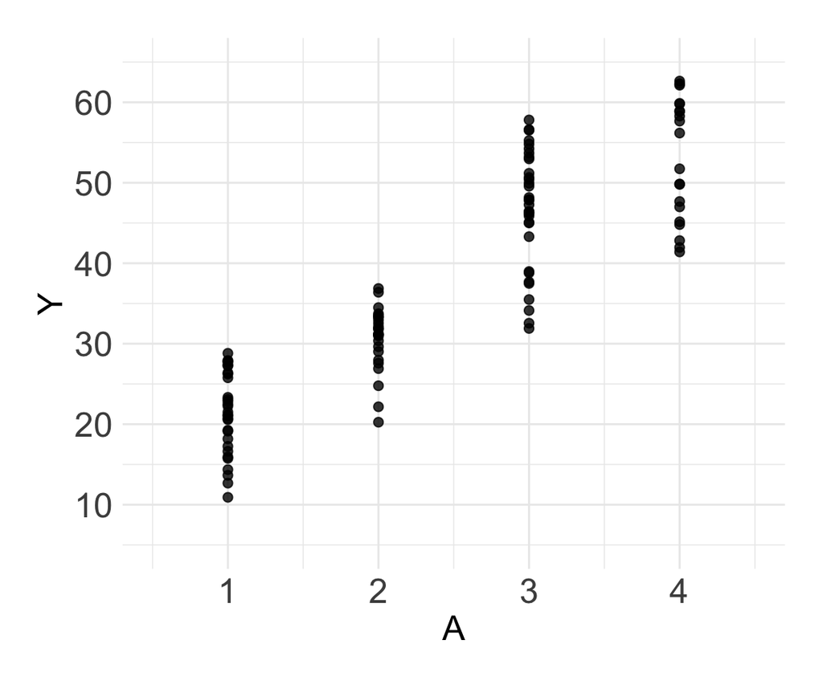

```r
# Generate synthetic data for left plot
set.seed(123)
n1 <- 30
n2 <- 25
n3 <- 35
n4 <- 20

# Data for A=1
a1_data <- data.frame(
  A = rep(1, n1),
  Y = c(runif(10, 10, 30), runif(20, 12, 28))
)

# Data for A=2
a2_data <- data.frame(
  A = rep(2, n2),
  Y = c(runif(8, 20, 30), runif(17, 30, 38))
)

# Data for A=3
a3_data <- data.frame(
  A = rep(3, n3),
  Y = c(runif(15, 30, 50), runif(20, 45, 58))
)

# Data for A=4
a4_data <- data.frame(
  A = rep(4, n4),
  Y = c(runif(10, 40, 55), runif(10, 55, 63))
)

# Combine data
plot1_data <- rbind(a1_data, a2_data, a3_data, a4_data)

# Create plot
library(ggplot2)
ggplot(plot1_data, aes(x = A, y = Y)) +
  geom_point(size = 2, alpha = 0.8) +
  scale_x_continuous(breaks = 1:4, limits = c(0.5, 4.5)) +
  scale_y_continuous(breaks = seq(10, 60, 10), limits = c(5, 65)) +
  theme_minimal() +
  theme(
    axis.title = element_text(size = 18),
    axis.text = element_text(size = 18),
    plot.margin = margin(20, 20, 20, 20)
  ) +
  labs(x = "A", y = "Y")
```

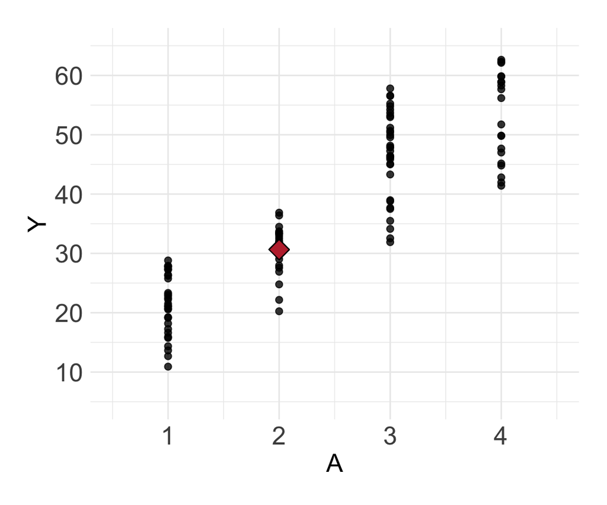

```r
mean.a2 <- mean(a2_data$Y)

# Create plot
ggplot(plot1_data, aes(x = A, y = Y)) +
  geom_point(size = 2, alpha = 0.8) +
  geom_point(size = 5, shape = 23, fill = "#be2f3a", aes(x = 2, y = mean.a2)) +
  scale_x_continuous(breaks = 1:4, limits = c(0.5, 4.5)) +
  scale_y_continuous(breaks = seq(10, 60, 10), limits = c(5, 65)) +
  theme_minimal() +
  theme(
    axis.title = element_text(size = 18),
    axis.text = element_text(size = 18),
    plot.margin = margin(20, 20, 20, 20)
  ) +
  labs(x = "A", y = "Y")
```

## Estimation

### Regression: intuition

$E[Y|A=5]$

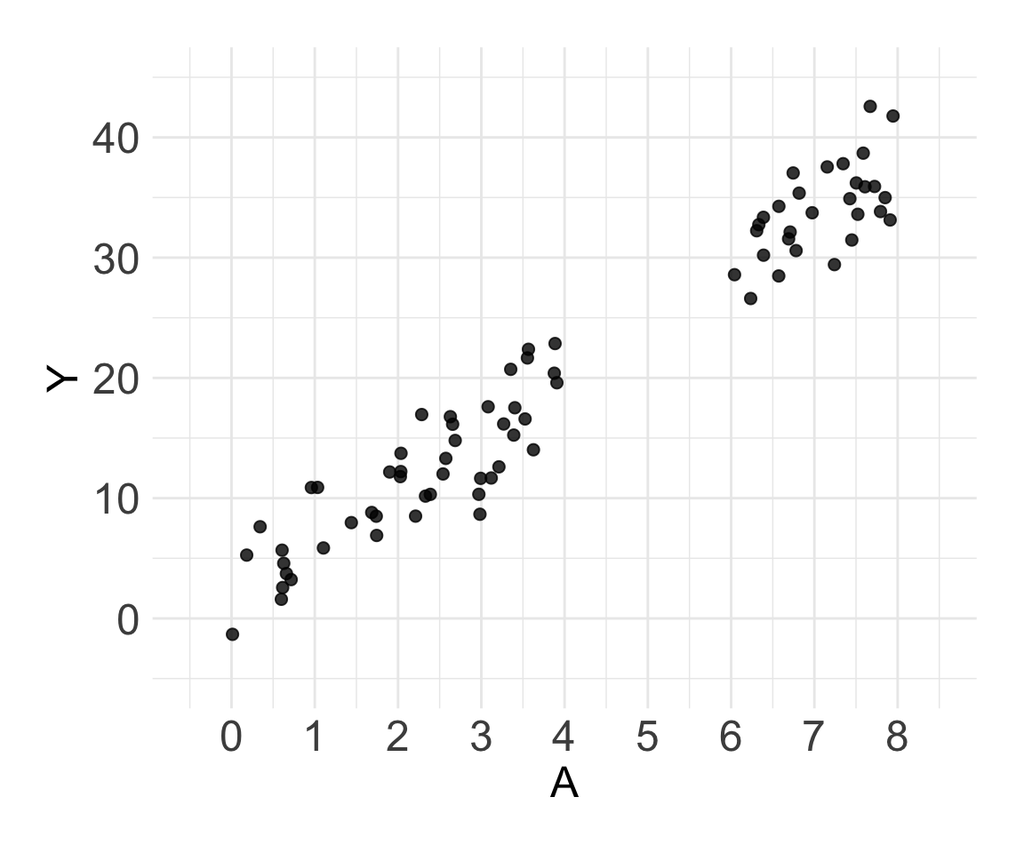

```r
# Generate synthetic data for right plot (more spread out)
set.seed(456)

# Create data with increasing trend
a_values <- runif(100, 0, 8)
y_values <- 2 + 4.5 * a_values + rnorm(100, 0, 3)
y_values <- pmax(y_values, -2)  # Ensure no negative values too extreme

plot2_data <- data.frame(A = a_values, Y = y_values)

# Remove observations with A = 5 (within tolerance)
plot2_data <- plot2_data[abs(plot2_data$A - 5) > 1, ]

# Create plot
ggplot(plot2_data, aes(x = A, y = Y)) +
  geom_point(size = 2, alpha = 0.8) +
  scale_x_continuous(breaks = 0:8, limits = c(-0.5, 8.5)) +
  scale_y_continuous(breaks = seq(0, 40, 10), limits = c(-5, 45)) +
  theme_minimal() +
  theme(
    axis.title = element_text(size = 18),
    axis.text = element_text(size = 18),
    plot.margin = margin(20, 20, 20, 20)
  ) +
  labs(x = "A", y = "Y")
```

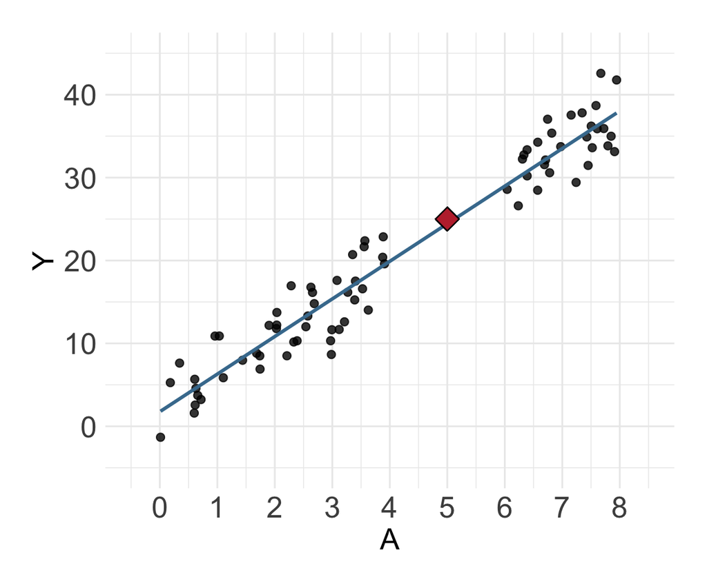

```r
# Create plot
ggplot(plot2_data, aes(x = A, y = Y)) +
  geom_point(size = 2, alpha = 0.8) +
  geom_smooth(method = "lm", se = F, color = "#457b9d") +
  geom_point(size = 5, shape = 23, fill = "#be2f3a", aes(x = 5, y = 25)) +
  scale_x_continuous(breaks = 0:8, limits = c(-0.5, 8.5)) +
  scale_y_continuous(breaks = seq(0, 40, 10), limits = c(-5, 45)) +
  theme_minimal() +
  theme(
    axis.title = element_text(size = 18),
    axis.text = element_text(size = 18),
    plot.margin = margin(20, 20, 20, 20)
  ) +
  labs(x = "A", y = "Y")
```

## Estimation

[figure not shown]

- Regression analysis
  - Making educated guess about conditional expected values
    - By borrowing information from other observations (model interpolation)
      - With modeling assumptions (e.g., linearity, no product terms)
        - CATE or ATE?
    - Pure prediction task after identification
      - Causal inference meets prediction!

**You get meaningless “numbers” with:**

- Good estimation but bad identification
- Good identification but bad estimation

## Modeling in Practice

- Simple model with stronger assumptions (most parametric regression)
  - More efficient but more biased
- Complex model with weaker assumptions
  - Less biased but less efficient

**Solutions to the bias-variance trade-off**

- Doubly-robust estimation (e.g., TMLE) <sup>1</sup>
- Non-parametric & data-adaptive approach (e.g., machine learning, SuperLearner) <sup>2</sup>
  - Generally better performance <sup>3</sup>
    - But potentially small gain with small and less complex data
      - Social epi?
[^3]: Schuler and Rose (2017)
[^4]: Smith et al. (2022)
[^5]: Rudolph et al. (2023)

## Causal Inference: Big Picture

[figure not shown]

- Unjustified fancy methods, unreasonable critiques
  - “Propensity scores can strengthen confounding adjustment!”
    - Identical conditional exchangeability assumption (Shiba and Kawahara 2021)
  - “Never use data-driven methods in causal research. Use theories!”
    - Could be useful for estimation.

**Always distinguish these steps when you learn, read, and respond**

## Summary 2

[figure not shown]

- Three steps of causal inference
  1. Specifying causal estimand
  2. Identification with assumptions
     - exchangeability, positivity, consistency
  3. Estimation via statistical models
- Interpretation & data

## Causal Inference in Social Epidemiology

[figure not shown]

- Data (Week 4)
  - Measuring intangible & complex social constructs
- Causal Estimand (Week 5)
  - Multi-level, distributional, population impacts
- Identification
  - Exchangeability (Week 3)
  - Consistency (Today)

## Consistency Assumption for Social Exposures

- $Y^a=Y$ when $A=a$
  - Intuition: “The observed outcome $Y$ of the exposed is equal to what the outcome would have been had they been exposed”
  - Corresponding interventions?

**Challenges**

- Multiple versions (compound treatment)
  - Crude definition (social participation, neighborhood vulnerability)
    - Often harder to achieve the treatment-variation irrelevance assumption
- Nonmanipulable?
  - What interventions would correspond to the “effect of race”?

## Galea-Hernan 2019 AJE Article

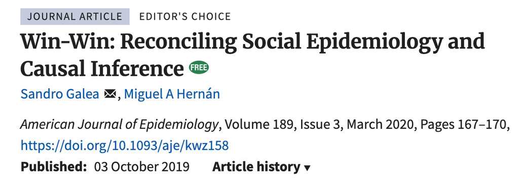

**Claim: Move to the right of the proposed spectrum of social exposures**

[figure not shown]

Figure 1 in (Galea and Hernán 2020)

## Responses to Galea & Hernan (2019)

### Responses concerning the consistency assumption for social exposures

1. Robinson and Bailey (2020)
   - Causal effect estimation is not the only goal of social epi
     - (Preliminary) evidence to “establish or rule out causation”
       - “Can genetic differences explain racial disparities?”
     - *Changes are driven by basic beliefs & narratives about causality, cultural values, attribution of moral responsibility rather than precise quantitative estimates*
   - Can fall into the “reductionism trap”
     - Finding “spiders” vs victim blaming (Krieger 1994)
2. Jackson and Arah (2020)
   - System preserving
   - Systems and effect

## Responses to Galea & Hernan (2019)

3. VanderWeele (2020)
   - Quantitative potential-outcome framework for social exposures on the “left end”

**Alternative approaches for ill-defined social exposures**

1. Redefine the exposure (to make modifiability more explicit)
2. Changing interpretation
3. Shifting the target of interventions

## Approach 1: Redefining Exposures

- The effect of “race”
  - Hypothetical intervention?
  - Changing skin color? Label assigned at birth?
  - Race as a social construct
    - Racism, discrimination, perceptions
      - e.g., White-sounding names got more interviews (Bertrand and Mullainathan 2004)
- Not saying we should avoid studies of “race”
  - Quantitative causal inference as a tool is more useful for well-defined exposures

## Approach 2: Changing Interpretation

- Social participation $A=1$ (vs no participation: $A=0$)
  - Version 1: ≥ once a week ($K(1)=1$)
  - Version 2: less often ($K(1)=2$)

**Possible interpretations**

1. Effect of “assigning” a compound treatment
   - $E[Y^{1}-Y^{0}]$
2. Weighted average of version-specific effects $Y^{a,k^a}$
   - $\sum{E[Y^{a,k^a}|A=a, K^a(a)=k^a]}{Pr[K^a(a)=k^a|A=a]}$
     - *Proposition 3* in (VanderWeele and Hernan 2013)
       - Additional conditioning on $L$ in observational studies
3. Effect of assigning a random draw from versions $K$
   - From observed distribution among $A=1$ vs $A=0$
     - & further conditioning on $L=l$ if confounding was adjusted

## Approach 3: Shifting The Target of Interventions

[figure not shown]

- The effect of SES on mitigating the racial disparity (VanderWeele and Robinson 2014)
  - What is the remaining association between race and the outcome, after fixing SES?
  - Often viewed as an extension of mediation
    - But does not require the conceptualization of an effect for the “exposure”

## Summary 3

- Consistency assumption is often challenging for social exposures
  - Unclear actions, lack of transportability, ill-informed study design
- In general, aim for well-defined & manipulable exposures
  - Imagine hypothetical interventions
  - (Perhaps less intuitive) interpretation available even when there are multiple versions
- But ask fundamental questions: What are the spiders that are producing inequalities?
  - Cutting the “web of causation” isn’t sufficient
  - The closer we get to the spiders, the less well-defined?
    - What is the goal of your “causal analysis”? Effect estimation or explanation?

## Assignment

- Problem set #2 (due September 22 at 9:55am)
- Reading quiz

## References

Bertrand M, Mullainathan S. Are emily and greg more employable than lakisha and jamal? A field experiment on labor market discrimination. American economic review. 2004;94(4):991–1013.

Carey EG, Ridler I, Ford TJ, Stringaris A. Editorial perspective: When is a ‘small effect’actually large and impactful? Journal of child psychology and psychiatry. 2023;64(11):1643–7.

Galea S, Hernán MA. Win-win: Reconciling social epidemiology and causal inference. American journal of epidemiology. 2020;189(3):167–70.

Hernán MA, Robins JM. Using big data to emulate a target trial when a randomized trial is not available. American journal of epidemiology. 2016;183(8):758–64.

Jackson JW, Arah OA. Invited commentary: Making causal inference more social and (social) epidemiology more causal. American journal of epidemiology. 2020;189(3):179–82.

Krieger N. Epidemiology and the web of causation: Has anyone seen the spider? Social science & medicine. 1994;39(7):887–903.

Petersen ML, Laan MJ van der. Causal models and learning from data: Integrating causal modeling and statistical estimation. Epidemiology. 2014;25(3):418–26.

Robinson WR, Bailey ZD. Invited commentary: What social epidemiology brings to the table—reconciling social epidemiology and causal inference. American journal of epidemiology. 2020;189(3):171–4.

Rose G. Sick individuals and sick populations. International journal of epidemiology. 1985;14(1):32–8.

Rudolph KE, Williams NT, Miles CH, Antonelli J, Diaz I. All models are wrong, but which are useful? Comparing parametric and nonparametric estimation of causal effects in finite samples. Journal of Causal Inference. 2023;11(1):20230022.

Schuler MS, Rose S. Targeted maximum likelihood estimation for causal inference in observational studies. American journal of epidemiology. 2017;185(1):65–73.

Shiba K, Kawahara T. Using propensity scores for causal inference: Pitfalls and tips. Journal of epidemiology. 2021;31(8):457–63.

Smith MJ, Mansournia MA, Maringe C, Zivich PN, Cole SR, Leyrat C, et al. Introduction to computational causal inference using reproducible stata, r, and python code: A tutorial. Statistics in medicine. 2022;41(2):407–32.

VanderWeele TJ. Invited commentary: Counterfactuals in social epidemiology—thinking outside of “the box.” American Journal of Epidemiology. 2020;189(3):175–8.

VanderWeele TJ, Hernan MA. Causal inference under multiple versions of treatment. Journal of causal inference. 2013;1(1):1–20.

VanderWeele TJ, Robinson WR. On the causal interpretation of race in regressions adjusting for confounding and mediating variables. Epidemiology. 2014;25(4):473–84.